# Breast Cancer Wisconsin (Diagnostic) Data Set

### from this plots my conclusion is:

```
1. there is a overlap in all the parameters, but the overlap in some of them is small enough that we could find parameters to distinguish between malingnant and benign.
2. the good variables to distinguish are:
    * all the size variables - radius, area, perimeter.
    * compactness
    * concavity
    * concave points
3. variables which are not good enough are:
    * smoothness
    * symmetry
    * fractal dimetion
```

### two variables correlations:

#### lets see correlations with heat map:

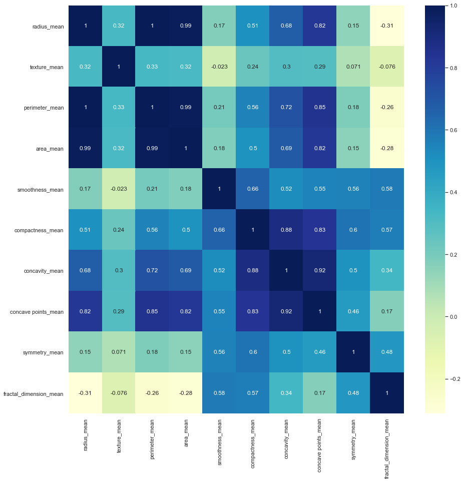

```python
plt.figure(figsize=(15,15))
ax = sns.heatmap(df_small.corr(), annot=True,cmap="YlGnBu")
```

#### we see strong correlations too between :

- perimeter,radius and area corr are approximaly 1, what says that we could refer them as one "size" variable!
- concave points_mean - perimeter_mean (0.85)
- compactness_mean - concavity_mean (0.88)
- concavity_mean - concave points_mean (0.92)

#### and what about the "worst" variables ? are they proportional to the normal ?

```python
normal_and_wotst =['id', 'diagnosis','radius_mean', 'texture_mean',
       'smoothness_mean', 'compactness_mean', 'concavity_mean',
       'concave points_mean', 'symmetry_mean', 'fractal_dimension_mean',
       'radius_worst', 'texture_worst',
       'smoothness_worst',
       'compactness_worst', 'concavity_worst', 'concave points_worst',
       'symmetry_worst', 'fractal_dimension_worst']
df_nor_and_wor = df[normal_and_wotst]
df_nor_and_wor.head(2)
```

|  | id | diagnosis | radius_mean | texture_mean | smoothness_mean | compactness_mean | concavity_mean | concave points_mean | symmetry_mean | fractal_dimension_mean | radius_worst | texture_worst | smoothness_worst | compactness_worst | concavity_worst | concave points_worst | symmetry_worst | fractal_dimension_worst |
| --- | --- | --- | --- | --- | --- | --- | --- | --- | --- | --- | --- | --- | --- | --- | --- | --- | --- | --- |
| 0 | 842302 | M | 17.99 | 10.38 | 0.11840 | 0.27760 | 0.3001 | 0.14710 | 0.2419 | 0.07871 | 25.38 | 17.33 | 0.1622 | 0.6656 | 0.7119 | 0.2654 | 0.4601 | 0.11890 |
| 1 | 842517 | M | 20.57 | 17.77 | 0.08474 | 0.07864 | 0.0869 | 0.07017 | 0.1812 | 0.05667 | 24.99 | 23.41 | 0.1238 | 0.1866 | 0.2416 | 0.1860 | 0.2750 | 0.08902 |

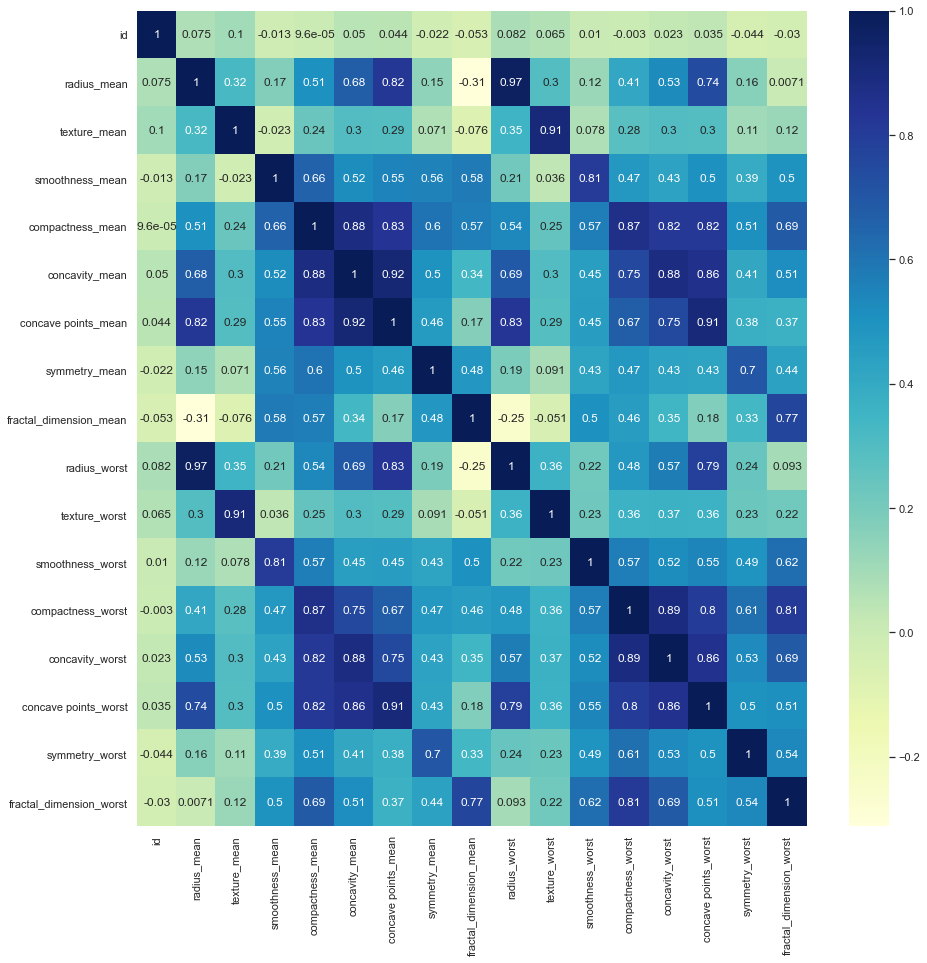

```python
plt.figure(figsize=(15,15))
ax = sns.heatmap(df_nor_and_wor.corr(), annot=True,cmap="YlGnBu")
```

## Multivariate Exploration

> Create plots of three or more variables to investigate your data even further. Make sure that your investigations are justified, and follow from your work in the previous sections.
1. "radius_mean", "concave points_mean" ,"diagnosis"

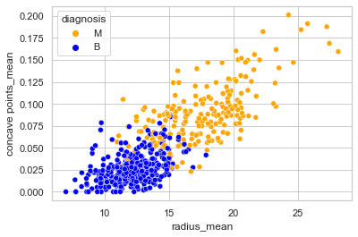

```python
pal = ['orange','blue']
sns.scatterplot(data=df_small, x="radius_mean", y="concave points_mean", hue="diagnosis",palette=pal);
```

#### we see here very good difference between M & B !

1. "radius_mean", "texture_mean", "diagnosis".

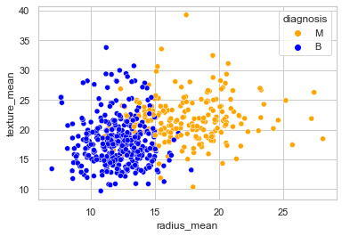

```python
sns.scatterplot(data=df_small, x="radius_mean", y="texture_mean", hue="diagnosis",palette=pal);
```

#### we see here different on the x axis, but it isn't good enough on the y axis.

1. "radius_mean", "smoothness_mean", "diagnosis".

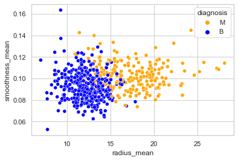

```python
sns.scatterplot(data=df_small, x="radius_mean", y="smoothness_mean", hue="diagnosis",palette=pal);
```

#### we see here different on the x axis, but it isn't good enough on the y axis.

1. "radius_mean", "compactness_mean", "diagnosis".

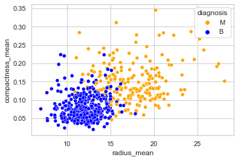

```python
sns.scatterplot(data=df_small, x="radius_mean", y="compactness_mean", hue="diagnosis",palette=pal);
```

#### we see here much better difference between M & B !

5."compactness_mean", "concave points_mean", "diagnosis".

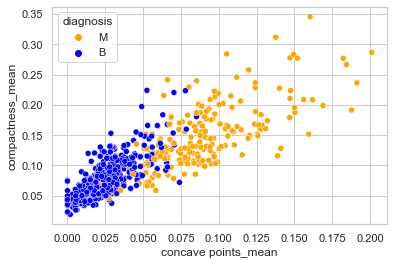

```python
sns.scatterplot(data=df_small, x="concave points_mean", y="compactness_mean", hue="diagnosis",palette=pal);
```

#### I think it's not bad too !

## All variables connections:

if we want to see other connections between two vars with shapes, we could see this greed:

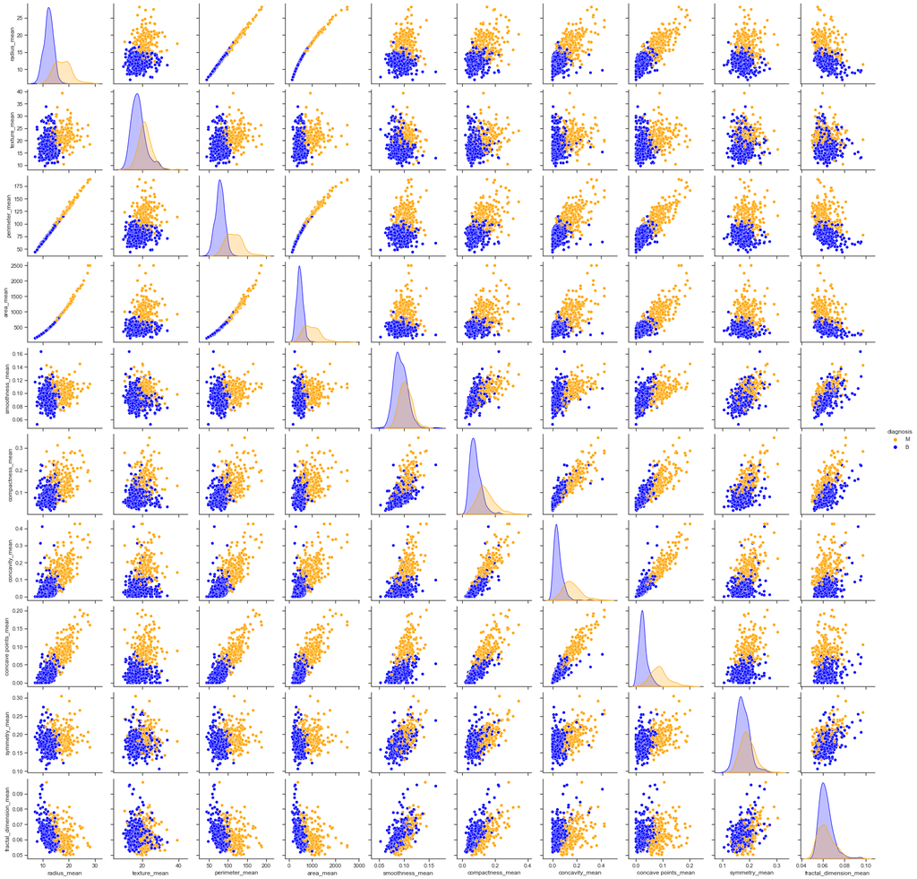

```python
sns.set(style="ticks")
pal = ['orange','blue']
sns.pairplot(df_small,palette=pal,hue="diagnosis");
```

## Conclusion:

- I think that the best predictable variables are:
  1. size variables (radius,perimeter,area) - they are proportional so i prefer them as 1 variable.
  2. compactness
  3. concave points_mean & concavity - they are proportional too.
- the combination of this 3 could predict if the tumor is malingnant or benign